# Lección: Economía e industria

## Solo sé que no sé nada

La frase “solo sé que no sé nada” se le atribuye a Sócrates que vivió en el siglo V antes de Cristo, según escribe su discípulo Platón. Aunque Sócrates estuviera convencido de que no sabía nada era claro que en esa época era el más sabio de los atenienses. Lo que decía Sócrates es también la común percepción de alguien que ha estudiado un tema durante varios años, cuanto más sabe más percibe lo que aun no sabe y le parece no saber mucho de toda la riqueza que encierra la realiad. Por eso un sabio, un sabio sincero, no deja nunca de aprender y sabe matizar sus opiniones sin creerse el dueño de la verdad.

Se presenta el caso de Michael Crichton, quien en su novela Estado de miedo cuestiona certezas sobre el calentamiento global usando datos reales. A través de gráficos, muestra que la relación entre temperatura y CO₂ no siempre es simple (por ejemplo, entre 1940 y 1970 la temperatura baja mientras el CO₂ sube), generando dudas en un personaje muy convencido.

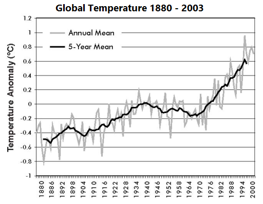

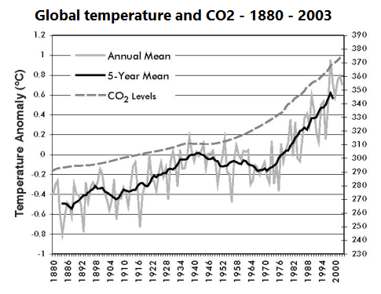

*Idea central:* la realidad es compleja; conviene evitar posturas absolutas y reconocer que en temas polémicos (como el cambio climático o la economía) influyen intereses, creencias y limitaciones en el conocimiento.

Chichton usó datos reales como [este](https://data.giss.nasa.gov/gistemp/graphs_v4/).

## Economía

### Fuente de lectura y consulta

[figure not shown]

La fuente es un libro llamado “Economía para el 99% de la población” escrito por Ha-Joon Chang que el autor se ha esmerado por escribir de modo sencilla.

### ¿Qué es la economía?

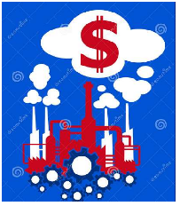

El profesor Chang expresa que la economía no es una ciencia exacta ni tampoco que abarca todas las cosas. Explica que la economía trata básicamente sobre el dinero. El dinero se puede obtener normalmente con el trabajo y pero también por transferencias en efectivo o en especies. El dinero ganado se consumen en bienes o servicios. Podemos decir que la ecoomí trata de todo ésto.

### Las leyes y principios en economía

Las leyes en economía no hay que tomarlas como las leyes físicas sino que hay que tener en cuenta al hombre y su libertad. No siempre las personas reaccionan como es esperable. El hombre tiene algo adentro que lo puede llevar a afrontar el más temido castigo por defender un principio o, por el contrario, puede dejarse llevar por la corriente y tal vez cometer grandes maldades sin casi darse cuenta. Esto está presente en la economía y en la vida misma.

Hay una película basada en un hecho real que muestra como alguien reacciona de un modo muy diferente a lo normal ante el hecho de una guerra. Se llama **Hasta el último hombre** y en este [link](https://www.youtube.com/watch?v=bSpqX6x97N0) se puede ver su trailer. **Es la historia de alguien que no hace lo que hacen todos**.

Algunas leyes de la economía como la de **“oferta-demanda”**, que epresa que si la demanda de un bien aumenta entonces también aumenta su precio, pueden no cumplirse en ciertas condiciones, por ejemplo si por motivaciones pratioticas en el que la gente decide no aumentar precios para poder pasar una crisis.

### La economía capitalista

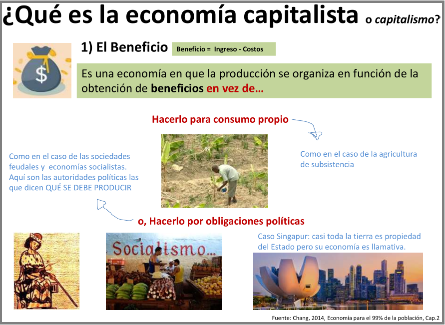

Lo que diferencia la economía capitalista de la socialista es básicamente que en el capitalismo la guía es la búsqueda de un **beneficio** mientras que en el socialismo la guía son las **obligaciones políticas** (trabajar para darle al estado los bienes para que supuestamente el estado los reparta equitativamente).

### Otros aspectos de la economía capitalista

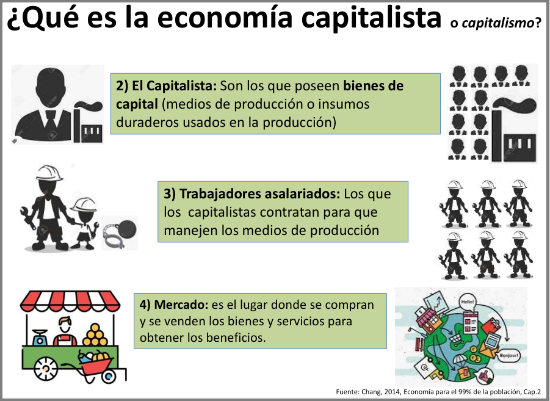

- Algunos comentarios más:
  - El capitalista: Al comienzo el dueño solía ser uno solo pero hoy las empresas suelen tener muchos dueños a través de las acciones